# Regressão linear na prática

## Dados da CAPES sobre avaliação da pós-graduação

A CAPES é um órgão do MEC que tem a atribuição de acompanhar a pós-graduação na universidade brasileira. Uma das formas que ela encontrou de fazer isso e pela qual ela é bastante criticada é através de uma avaliação quantitativa a cada x anos (era 3, mudou para 4).

Usaremos dados da penúltima avaliação da CAPES:

```r
cacc = read_projectdata()
glimpse(cacc)
```

```
Observations: 73
Variables: 31
$ Instituicao                  <chr> "UNIVERSIDADE FEDERAL DO AMAZONAS", "UNIVER...
$ Programa                     <chr> "INFORMÁTICA (12001015012P2)", "CIÊNCIA DA ...
$ Nível                        <int> 5, 4, 3, 3, 3, 5, 4, 3, 3, 3, 5, 3, 3, 3, 4...
$ Sigla                        <chr> "UFAM", "UFPA", "UFMA", "UEMA", "FUFPI", "U...
$ `Tem doutorado`              <chr> "Sim", "Sim", "Não", "Não", "Não", "Sim", "...
$ `Docentes colaboradores`     <dbl> 0.25, 5.50, 3.00, 6.25, 1.75, 2.00, 1.00, 6...
$ `Docentes permanentes`       <dbl> 24.75, 14.00, 10.00, 14.00, 9.50, 20.75, 16...
$ `Docentes visitantes`        <dbl> 0.00, 0.00, 0.00, 0.00, 0.00, 0.75, 0.50, 1...
$ `Resumos em conf`            <int> 20, 23, 15, 5, 4, 10, 6, 136, 0, 24, 27, 4,...
$ `Resumos expandidos em conf` <int> 25, 24, 7, 10, 1, 68, 9, 13, 4, 6, 16, 5, 2...
$ `Artigos em conf`            <int> 390, 284, 115, 73, 150, 269, 179, 0, 120, 9...
$ Dissertacoes                 <int> 108, 77, 50, 25, 31, 75, 60, 129, 45, 3, 10...
$ Teses                        <int> 14, 0, 0, 0, 0, 24, 5, 0, 0, 0, 29, 0, 0, 0...
```

[output cut: 18 more lines]

### Produção e produtividade de artigos

Uma das maneiras de avaliar a produção dos docentes que a CAPES utiliza é quantificando a produção de artigos pelos docentes. Os artigos são categorizados em extratos ordenados (A1 é o mais alto), e separados entre artigos em conferências e periódicos. Usaremos para esse lab a produção em periódicos avaliados com A1, A2 e B1.

```r
cacc = cacc %>%
  mutate(producao = (periodicos_A1 + periodicos_A2 + periodicos_B1),
         produtividade = producao / `Docentes permanentes`,
         mestrados = Dissertacoes,
         doutorados = Teses,
         mestrados_pprof = mestrados / `Docentes permanentes`,
         doutorados_pprof = doutorados / `Docentes permanentes`)
```

### EDA

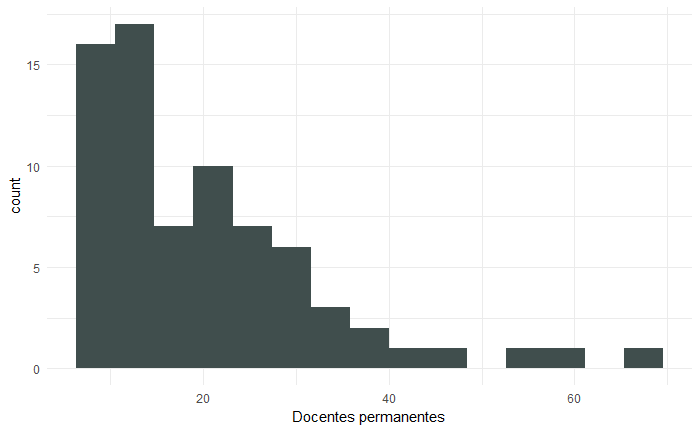

```r
cacc %>%
  ggplot(aes(x = `Docentes permanentes`)) +
  geom_histogram(bins = 15, fill = paleta[1])
```

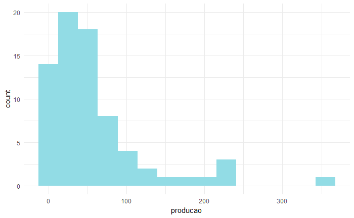

```r
cacc %>%
  ggplot(aes(x = producao)) +
  geom_histogram(bins = 15, fill = paleta[2])
```

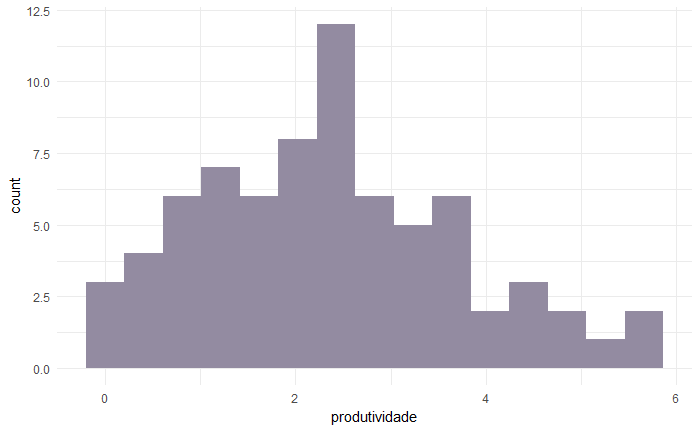

```r
cacc %>%
  ggplot(aes(x = produtividade)) +
  geom_histogram(bins = 15, fill = paleta[3])
```

Se quisermos modelar o efeito do tamanho do programa em termos de docentes (permanentes) na quantidade de artigos publicados, podemos usar regressão.

*Importante*: sempre queremos ver os dados antes de fazermos qualquer modelo ou sumário:

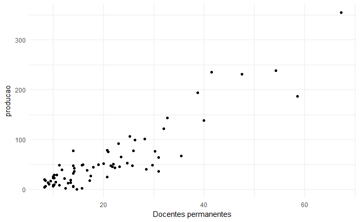

```r
cacc %>%
  ggplot(aes(x = `Docentes permanentes`, y = producao)) +
  geom_point()
```

```r
# This block was derivated from the previous one to try another view with same scale on both axis.
#cacc %>%
#  ggplot(aes(x = `Docentes permanentes`, y = producao)) +
#  geom_point() +
#  scale_x_continuous(limits = c(0,300))
```

Parece que existe uma relação. Vamos criar um modelo então:

```r
modelo1 = lm(producao ~ `Docentes permanentes`, data = cacc)
tidy(modelo1, conf.int = TRUE, conf.level = 0.95)
```

```
                    term  estimate std.error statistic      p.value   conf.low
1            (Intercept) -41.27309 6.5299245 -6.320607 2.014731e-08 -54.293387
2 `Docentes permanentes`   4.81337 0.2725331 17.661601 1.088465e-27   4.269955
   conf.high
1 -28.252788
2   5.356786
```

```r
glance(modelo1)
```

```
  r.squared adj.r.squared    sigma statistic      p.value df    logLik      AIC
1 0.8145886     0.8119771 28.37407  311.9322 1.088465e-27  2 -346.7883 699.5766
       BIC deviance df.residual
1 706.4479 57161.22          71
```

Para visualizar o modelo:

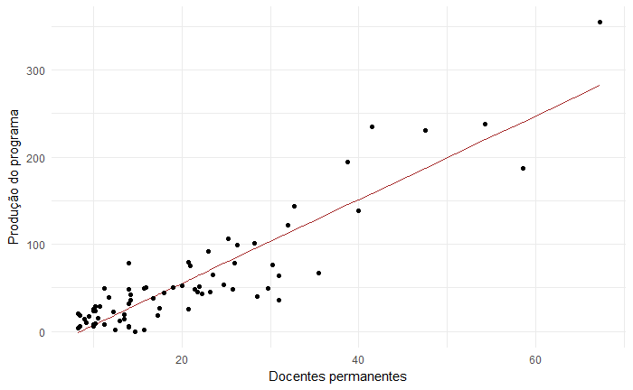

```r
cacc_augmented = cacc %>%
  add_predictions(modelo1)
cacc_augmented %>%
  ggplot(aes(x = `Docentes permanentes`)) +
  geom_line(aes(y = pred), colour = "brown") +
  geom_point(aes(y = producao)) +
  labs(y = "Produção do programa")
```

Se considerarmos que temos apenas uma amostra de todos os programas de pós em CC no Brasil, o que podemos inferir a partir desse modelo sobre a relação entre número de docentes permanentes e produção de artigos em programas de pós?

Normalmente reportaríamos o resultado da seguinte maneira, substituindo VarIndepX e todos os x’s e y’s pelos nomes e valores de fato:

> Regressão múltipla foi utilizada para analisar se VarIndep1 e VarIndep2 tem uma associação significativa com VarDep. Os resultados da regressão indicam que um modelo com os 2 preditores no formato VarDep = XXX.VarIndep1 + YYY.VarIndep2 explicam XX,XX% da variância da variável de resposta (R2 = XX,XX). VarIndep1, medida como/em [unidade ou o que é o 0 e o que é 1] tem uma relação significativa com o erro (b = [yy,yy; zz,zz], IC com 95%), assim como VarIndep2 medida como [unidade ou o que é o 0 e o que é 1] (b = [yy,yy; zz,zz], IC com 95%). O aumento de 1 unidade de VarIndep1 produz uma mudança de xxx em VarDep, enquanto um aumento…

Produza aqui a sua versão desse texto, portanto:

Regressão linear foi utilizada para analisar se *a quantidade de docentes permanentes num dado programa de pós-graduação* tem uma associação significativa com *a produção do respectivo programa*, esta última medida em termos da quantidade de publicações em períodicos dos extratos A1, A2 e B1. Os resultados da regressão indicam que um modelo com *1 preditor* no formato *producao = -41,27 + 4,81.docentes_permanentes* explicam *81,46%* da variância da variável de resposta (R2 = *81,46%*). *Quantidade de docentes*, medida *em pessoas que integram o programa*, tem uma relação significativa com o erro (b = *[4,27; 5,36]*, IC com 95%). O aumento de 1 unidade de *quantidade de docentes permanentes* gera uma mudança positiva de *4,81 na produção do programa*.

Dito isso, o que significa a relação que você encontrou na prática para entendermos os programas de pós graduação no Brasil? E algum palpite de por que a relação que encontramos é forte?

Pela análise realizada, verificamos que a quantidade de docentes permanentes e a produção de um programa são duas características associadas positivamente de maneira significativa. Isso é o mesmo que dizer que o crescimento de uma ocorre junto com o crescimento da outra, precisamente a uma taxa estatisticamente esperada de +4,81 unidades de produção para cada docente a mais no programa. Todavia, precisamos ter cuidado na compreensão desse resultado, pois apesar de mencionarmos uma em função da outra, não podemos, no entanto, afirmar que haja qualquer relação de causalidade entre elas, mas apenas que elas têm alguma espécie de relacionamento. Por outro lado, podemos imaginar que a quantidade de docente, de fato, implique em maiores quantitativos de produção, uma vez que havendo mais pessoas, espera-se realmente que elas estejam trabalhando e publicando mais conteúdo.

## Mais fatores

E se considerarmos também o número de alunos?

```r
modelo2 = lm(producao ~ `Docentes permanentes` + mestrados + doutorados, data = cacc)
tidy(modelo2, conf.int = TRUE, conf.level = 0.95)
```

```
                    term    estimate  std.error statistic      p.value    conf.low
1            (Intercept) -14.3663077 7.45407703 -1.927309 5.805909e-02 -29.2367845
2 `Docentes permanentes`   3.4997112 0.45965441  7.613788 1.015822e-10   2.5827257
3              mestrados  -0.1949515 0.08159627 -2.389221 1.962240e-02  -0.3577316
4             doutorados   1.0007711 0.18309265  5.465927 6.874998e-07   0.6355112
   conf.high
1  0.5041691
2  4.4166967
3 -0.0321714
4  1.3660309
```

```r
glance(modelo2)
```

```
  r.squared adj.r.squared    sigma statistic      p.value df    logLik      AIC
1 0.8706642     0.8650409 24.03905  154.8316 1.416348e-30  4 -333.6422 677.2845
       BIC deviance df.residual
1 688.7368 39873.45          69
```

Visualizar o modelo com muitas variáveis independentes fica mais difícil

```r
para_plotar_modelo = cacc %>%
  data_grid(producao = seq_range(producao, 10), # Crie um vetor de 10 valores no range
            `Docentes permanentes` = seq_range(`Docentes permanentes`, 4),
            # mestrados = seq_range(mestrados, 3),
            mestrados = median(mestrados),
            doutorados = seq_range(doutorados, 3)) %>%
  add_predictions(modelo2)
glimpse(para_plotar_modelo)
```

```
Observations: 120
Variables: 5
$ producao               <dbl> 0.00000, 0.00000, 0.00000, 0.00000, 0.00000, 0.00...
$ `Docentes permanentes` <dbl> 8.25000, 8.25000, 8.25000, 27.91667, 27.91667, 27...
$ mestrados              <int> 58, 58, 58, 58, 58, 58, 58, 58, 58, 58, 58, 58, 5...
$ doutorados             <dbl> 0, 76, 152, 0, 76, 152, 0, 76, 152, 0, 76, 152, 0...
$ pred                   <dbl> 3.199123, 79.257725, 155.316327, 72.026777, 148.0...
```

[figure not shown]

Considerando agora esses três fatores, o que podemos dizer sobre como cada um deles se relaciona com a produção de um programa de pós em CC? E sobre o modelo? Ele explica mais que o modelo 1?

## Agora produtividade

Diferente de medirmos produção (total produzido), é medirmos produtividade (produzido / utilizado). Abaixo focaremos nessa análise. Para isso crie um modelo que investiga como um conjunto de fatores que você julga que são relevantes se relacionam com a produtividade dos programas. Crie um modelo que avalie como *pelo menos 3 fatores* se relacionam com a produtividade de um programa. Pode reutilizar fatores que já definimos e analizamos para produção. Mas cuidado para não incluir fatores que sejam função linear de outros já incluídos (ex: incluir A, B e um tercero C=A+B)

Produza abaixo o modelo e um texto que comente (i) o modelo, tal como os que fizemos antes, e (ii) as implicações - o que aprendemos sobre como funcionam programas de pós no brasil?.